# D2SC: Weekly Assignments

Abhi Patel

2024-11-14

```r
library(tidyverse)
```

# Assignment 1

To be able to figure out how to load a library in R, I went to google and searched up “load libraries in r”. Then, I clicked on the top result as the description seemed to be what I was looking for. This was https://bookdown.org/nana/intror/install-and-load-packages.html. This gave me the instructions for both installing packages as well as loading libraries. I used the loading libraries instruction it suggested and ran it in a R code chunk. It ended up working correctly.

```r
? tidyverse
```

```
## starting httpd help server ... done
```

The ‘tidyverse’ is a set of packages that work in harmony because they share common data representations and ‘API’ design. This package is designed to make it easy to install and load multiple ‘tidyverse’ packages in a single step. Learn more about the ‘tidyverse’ at https://www.tidyverse.org.

# Assignment 2

```r
relational_task<-read_csv("tidy_data/MFIndD_analogy.csv")
print(relational_task)
```

```
## # A tibble: 792 × 6
##    qualtrics_id    trial_number match_type_0 match_type_1 response response_type
##    <chr>                  <dbl> <chr>        <chr>           <dbl> <chr>
##  1 R_2dlRKzx851f1…            3 Rel          Obj                 1 Obj
##  2 R_2dlRKzx851f1…            4 Rel          Obj                 1 Obj
##  3 R_2dlRKzx851f1…            1 Rel          Obj                 1 Obj
##  4 R_2dlRKzx851f1…            6 Obj          Rel                 0 Obj
##  5 R_2dlRKzx851f1…            5 Obj          Rel                 0 Obj
##  6 R_2dlRKzx851f1…            8 Obj          Rel                 0 Obj
##  7 R_2dlRKzx851f1…            2 Rel          Obj                 1 Obj
##  8 R_2dlRKzx851f1…            7 Obj          Rel                 0 Obj
##  9 R_Qb1tzaskoeU0…            7 Obj          Rel                 0 Obj
## 10 R_Qb1tzaskoeU0…            1 Rel          Obj                 1 Obj
## # ℹ 782 more rows
```

“qualtrics_id” is the column that contains the unique identifier for each participant.

```r
glimpse(relational_task)
```

```
## Rows: 792
## Columns: 6
## $ qualtrics_id  <chr> "R_2dlRKzx851f1Yd9", "R_2dlRKzx851f1Yd9", "R_2dlRKzx851f…
## $ trial_number  <dbl> 3, 4, 1, 6, 5, 8, 2, 7, 7, 1, 6, 2, 4, 8, 5, 3, 8, 6, 3,…
## $ match_type_0  <chr> "Rel", "Rel", "Rel", "Obj", "Obj", "Obj", "Rel", "Obj", …
## $ match_type_1  <chr> "Obj", "Obj", "Obj", "Rel", "Rel", "Rel", "Obj", "Rel", …
## $ response      <dbl> 1, 1, 1, 0, 0, 0, 1, 0, 0, 1, 0, 1, 1, 0, 0, 1, 0, 1, 0,…
## $ response_type <chr> "Obj", "Obj", "Obj", "Obj", "Obj", "Obj", "Obj", "Obj", …
```

The dataset has 792 rows and 6 columns. I got this information using the glimpse() function which allows us to get an idea of the data that we are seeing. This function also shows the number of rows and columns as a part of this

```r
relational_task%>%
  distinct(qualtrics_id)%>%
  count()
```

```
## # A tibble: 1 × 1
##       n
##   <int>
## 1    99
```

There are 99 people in the dataset.

```r
relational_task%>%
  group_by(qualtrics_id)%>%
  summarize(num_trials = n())%>%
  distinct(num_trials)
```

```
## # A tibble: 1 × 1
##   num_trials
##        <int>
## 1          8
```

All participants have data from the same number of trials. In this dataset, it seems to be 8 trials per participant.

# Assignment 3

```r
library(ggplot2)
```

```r
relational_response_type<-
relational_task%>%
  group_by(qualtrics_id)%>%
  summarize(num_relational_matches = sum(response_type=="Rel"))%>%
  ungroup()
```

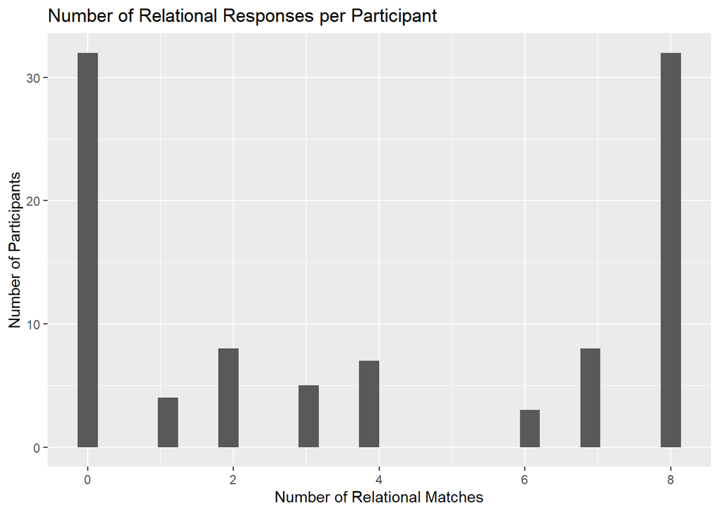

```r
relational_response_type %>%
  ggplot(aes(x=num_relational_matches)) +
  geom_histogram()+
  labs(title = "Number of Relational Responses per Participant", y = "Number of Participants", x = "Number of Relational Matches")
```

I notice that 0 and 8 relational matches seem to have the highest amount of participants associated with . All the number of relational matches in the middle seem to be considerably smaller and relatively even. Perhaps, this may suggest that a person has a tendency to either choose a relational_match or not choose it at all.

```r
reshaped_relational_task<-
  relational_task%>%
  select(qualtrics_id, trial_number, response_type) %>%
  arrange(trial_number)%>%
  pivot_wider(names_from = trial_number, values_from = response_type)
  reshaped_relational_task
```

```
## # A tibble: 99 × 9
##    qualtrics_id      `1`   `2`   `3`   `4`   `5`   `6`   `7`   `8`
##    <chr>             <chr> <chr> <chr> <chr> <chr> <chr> <chr> <chr>
##  1 R_2dlRKzx851f1Yd9 Obj   Obj   Obj   Obj   Obj   Obj   Obj   Obj
##  2 R_Qb1tzaskoeU0kLf Obj   Obj   Obj   Obj   Obj   Obj   Obj   Obj
##  3 R_8AGSWBQpPasvjmp Rel   Rel   Rel   Rel   Rel   Rel   Rel   Obj
##  4 R_1Tv8RlXGXRDH6BX Obj   Obj   Obj   Obj   Obj   Obj   Obj   Obj
##  5 R_3p3Glk1o4y2BcRe Obj   Obj   Obj   Obj   Obj   Obj   Obj   Rel
##  6 R_NVYrJklfFqRVOnv Obj   Obj   Obj   Obj   Obj   Obj   Obj   Obj
##  7 R_u4J8rwDfOmm4gYV Obj   Rel   Obj   Rel   Rel   Rel   Obj   Obj
##  8 R_1lnLF0rQ3biXSbK Obj   Rel   Rel   Rel   Rel   Rel   Rel   Rel
##  9 R_3Mm44PUN5bz3OjI Obj   Obj   Obj   Obj   Obj   Obj   Obj   Obj
## 10 R_1F9e3CRe4Tb8JhE Rel   Rel   Obj   Obj   Obj   Obj   Obj   Obj
## # ℹ 89 more rows
```

```r
relational_response_type %>%
  ggplot(aes(x=num_relational_matches,
             y = qualtrics_id)) +
  geom_histogram()+
  labs(title = "Number of Relational Responses per Participant",
       y = "Number of Participants",
       x = "Number of Relational Matches")
```

It turns out that you can only set one axes equal to a column in the aesthetic. I was trying to do it as if setting the x and y variables for a graph, but it wasn’t working like that. Nor would it have been correct in hindsight for the question asked. I resolved the error by only having x = num_relational_matches such that we have a histogram that answers the question and solves the error.

# Assignment 4

```r
library(ggplot2)
library(dplyr)
```

```r
rational_task<-read_csv("tidy_data/MFIndD_REI.csv")
head(rational_task)
```

```
## # A tibble: 6 × 6
##   qualtrics_id      sub_type item_number rev_scoring response scored_response
##   <chr>             <chr>          <dbl> <chr>       <chr>              <dbl>
## 1 R_1lnLF0rQ3biXSbK RE                 1 neg         2                      4
## 2 R_1lnLF0rQ3biXSbK RA                 1 neg         4                      2
## 3 R_1lnLF0rQ3biXSbK RE                 2 <NA>        3                      3
## 4 R_1lnLF0rQ3biXSbK RA                 2 neg         3                      3
## 5 R_1lnLF0rQ3biXSbK RE                 3 neg         2                      4
## 6 R_1lnLF0rQ3biXSbK RE                 4 <NA>        2                      2
```

```r
typeof(rational_task$scored_response)
```

```
## [1] "double"
```

The column type of the response column is type character. The column type of the scored_response column is type double. They are different even they both contain numbers because the response column includes 1-5 and Strongly Disagree to Strongly Agree as t for one and the other in the response as per the likert scale. The scored response is a double that takes into account any reverse scoring to give a numerical output.

```r
rational_task <- rational_task %>%
  mutate(response_numeric = case_when(
    response == "Strongly Disagree" ~ 1,
    response == "Disagree" ~ 2,
    response == "Neutral" ~ 3,
    response == "Agree" ~ 4,
    response == "Strongly Agree" ~ 5,
    response == "1" ~ 1,
    response == "2" ~ 2,
    response == "3" ~ 3,
    response == "4" ~ 4,
    response == "5" ~ 5,
    TRUE ~ NA_real_  # NA for any unexpected values
  ))
rational_task
```

```
## # A tibble: 4,000 × 7
##    qualtrics_id      sub_type item_number rev_scoring response scored_response
##    <chr>             <chr>          <dbl> <chr>       <chr>              <dbl>
##  1 R_1lnLF0rQ3biXSbK RE                 1 neg         2                      4
##  2 R_1lnLF0rQ3biXSbK RA                 1 neg         4                      2
##  3 R_1lnLF0rQ3biXSbK RE                 2 <NA>        3                      3
##  4 R_1lnLF0rQ3biXSbK RA                 2 neg         3                      3
##  5 R_1lnLF0rQ3biXSbK RE                 3 neg         2                      4
##  6 R_1lnLF0rQ3biXSbK RE                 4 <NA>        2                      2
##  7 R_1lnLF0rQ3biXSbK RE                 5 neg         2                      4
##  8 R_1lnLF0rQ3biXSbK RA                 3 neg         2                      4
##  9 R_1lnLF0rQ3biXSbK RA                 4 neg         2                      4
## 10 R_1lnLF0rQ3biXSbK RE                 6 <NA>        2                      2
## # ℹ 3,990 more rows
## # ℹ 1 more variable: response_numeric <dbl>
```

```r
rational_task<-rational_task%>%
  mutate(new_scored_response = ifelse(!is.na(rev_scoring),
                                      6-response_numeric,
                                      response_numeric))
rational_task
```

```
## # A tibble: 4,000 × 8
##    qualtrics_id      sub_type item_number rev_scoring response scored_response
##    <chr>             <chr>          <dbl> <chr>       <chr>              <dbl>
##  1 R_1lnLF0rQ3biXSbK RE                 1 neg         2                      4
##  2 R_1lnLF0rQ3biXSbK RA                 1 neg         4                      2
##  3 R_1lnLF0rQ3biXSbK RE                 2 <NA>        3                      3
##  4 R_1lnLF0rQ3biXSbK RA                 2 neg         3                      3
##  5 R_1lnLF0rQ3biXSbK RE                 3 neg         2                      4
##  6 R_1lnLF0rQ3biXSbK RE                 4 <NA>        2                      2
##  7 R_1lnLF0rQ3biXSbK RE                 5 neg         2                      4
##  8 R_1lnLF0rQ3biXSbK RA                 3 neg         2                      4
##  9 R_1lnLF0rQ3biXSbK RA                 4 neg         2                      4
## 10 R_1lnLF0rQ3biXSbK RE                 6 <NA>        2                      2
## # ℹ 3,990 more rows
## # ℹ 2 more variables: response_numeric <dbl>, new_scored_response <dbl>
```

```r
differences<-rational_task%>%
  filter(scored_response!=new_scored_response)
differences
```

```
## # A tibble: 0 × 8
## # ℹ 8 variables: qualtrics_id <chr>, sub_type <chr>, item_number <dbl>,
## #   rev_scoring <chr>, response <chr>, scored_response <dbl>,
## #   response_numeric <dbl>, new_scored_response <dbl>
```

# Assignment 5

```r
summarized_REI<-read_csv("tidy_data/MFIndD_REI.csv")%>%
  group_by(qualtrics_id, sub_type)%>%
  summarize(score = sum(scored_response))
print(summarized_REI)
```

```
## # A tibble: 400 × 3
## # Groups:   qualtrics_id [100]
##    qualtrics_id      sub_type score
##    <chr>             <chr>    <dbl>
##  1 R_0SrX3uRtXaupbhv EA          31
##  2 R_0SrX3uRtXaupbhv EE          25
##  3 R_0SrX3uRtXaupbhv RA          38
##  4 R_0SrX3uRtXaupbhv RE          37
##  5 R_0V8O8mrLiHO3Ghj EA          22
##  6 R_0V8O8mrLiHO3Ghj EE          22
##  7 R_0V8O8mrLiHO3Ghj RA          42
##  8 R_0V8O8mrLiHO3Ghj RE          42
##  9 R_1BW5H5J1jQFEpuk EA          32
## 10 R_1BW5H5J1jQFEpuk EE          25
## # ℹ 390 more rows
```

```r
NA_scores <- summarized_REI %>%
  filter(is.na(score))
NA_scores
```

```
## # A tibble: 13 × 3
## # Groups:   qualtrics_id [11]
##    qualtrics_id      sub_type score
##    <chr>             <chr>    <dbl>
##  1 R_1F9e3CRe4Tb8JhE RE          NA
##  2 R_1lnLF0rQ3biXSbK RA          NA
##  3 R_25FgHNiNx7jLHy1 EA          NA
##  4 R_2c60t6KOIDTWPQb RE          NA
##  5 R_3NV67BeT8swOBOf RA          NA
##  6 R_3frS5bkaT1hzbPh EA          NA
##  7 R_3frS5bkaT1hzbPh EE          NA
##  8 R_3frS5bkaT1hzbPh RA          NA
##  9 R_OxLEJkniZlsCYut EE          NA
## 10 R_STy7opVLSgSa2uB EE          NA
## 11 R_ZsMPn5XJ1D0EdDX RA          NA
## 12 R_pgCwFopl4N7tYjf RE          NA
## 13 R_u4J8rwDfOmm4gYV RE          NA
```

```r
?summarize
```

Yes, there are NAs

```r
summarized_REI<-read_csv("tidy_data/MFIndD_REI.csv")%>%
  group_by(qualtrics_id, sub_type)%>%
  summarize(score = sum(scored_response, na.rm = TRUE))
print(summarized_REI)
```

```
## # A tibble: 400 × 3
## # Groups:   qualtrics_id [100]
##    qualtrics_id      sub_type score
##    <chr>             <chr>    <dbl>
##  1 R_0SrX3uRtXaupbhv EA          31
##  2 R_0SrX3uRtXaupbhv EE          25
##  3 R_0SrX3uRtXaupbhv RA          38
##  4 R_0SrX3uRtXaupbhv RE          37
##  5 R_0V8O8mrLiHO3Ghj EA          22
##  6 R_0V8O8mrLiHO3Ghj EE          22
##  7 R_0V8O8mrLiHO3Ghj RA          42
##  8 R_0V8O8mrLiHO3Ghj RE          42
##  9 R_1BW5H5J1jQFEpuk EA          32
## 10 R_1BW5H5J1jQFEpuk EE          25
## # ℹ 390 more rows
```

```r
NA_scores <- summarized_REI %>%
  filter(is.na(score))
NA_scores
```

```
## # A tibble: 0 × 3
## # Groups:   qualtrics_id [0]
## # ℹ 3 variables: qualtrics_id <chr>, sub_type <chr>, score <dbl>
```

```r
combined_data<-
  left_join(summarized_REI, relational_response_type, by="qualtrics_id")%>%
  filter(!is.na(num_relational_matches))
combined_data
```

```
## # A tibble: 396 × 4
## # Groups:   qualtrics_id [99]
##    qualtrics_id      sub_type score num_relational_matches
##    <chr>             <chr>    <dbl>                  <int>
##  1 R_0SrX3uRtXaupbhv EA          31                      0
##  2 R_0SrX3uRtXaupbhv EE          25                      0
##  3 R_0SrX3uRtXaupbhv RA          38                      0
##  4 R_0SrX3uRtXaupbhv RE          37                      0
##  5 R_0V8O8mrLiHO3Ghj EA          22                      8
##  6 R_0V8O8mrLiHO3Ghj EE          22                      8
##  7 R_0V8O8mrLiHO3Ghj RA          42                      8
##  8 R_0V8O8mrLiHO3Ghj RE          42                      8
##  9 R_1BW5H5J1jQFEpuk EA          32                      8
## 10 R_1BW5H5J1jQFEpuk EE          25                      8
## # ℹ 386 more rows
```

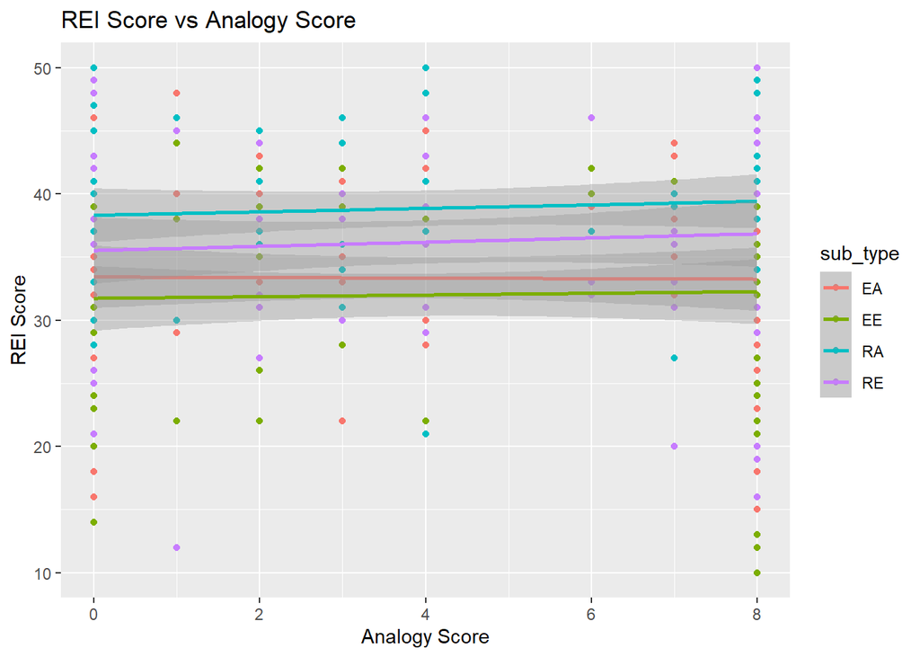

```r
combined_data %>%
  ggplot(aes(
    x=num_relational_matches,
    y=score,
    color=sub_type)) +
  geom_point()+
  geom_smooth(method = "lm")+
  labs(title = "REI Score vs Analogy Score",
       y = "REI Score",
       x = "Analogy Score")
```

The relation in the scatter plot seems to be that the maximum REI Scores happen at around the Analogy score of 0 and 8. If we are looking at the regression lines, it seems that the subtypes in order of the highest REI Scores to lowest across the analogy scores, seem to be RA, RE,EA,and EE.

# Assignment 6

```r
prob_task<-read_csv("tidy_data/MFIndD_probtask.csv")
prob_task
```

```
## # A tibble: 26,136 × 20
##    SubID    condition discreteness regularity integration major_color rt_toolong
##    <chr>    <chr>     <chr>        <chr>      <chr>       <chr>            <dbl>
##  1 R_2dlRK… dots_EqS… discrete     irregular  separated   blue                 0
##  2 R_2dlRK… dots_EqS… discrete     irregular  separated   blue                 0
##  3 R_2dlRK… dots_EqS… discrete     irregular  separated   blue                 0
##  4 R_2dlRK… dots_EqS… discrete     irregular  separated   blue                 0
##  5 R_2dlRK… dots_EqS… discrete     irregular  separated   blue                 0
##  6 R_2dlRK… dots_EqS… discrete     irregular  separated   blue                 0
##  7 R_2dlRK… dots_EqS… discrete     irregular  separated   blue                 0
##  8 R_2dlRK… dots_EqS… discrete     irregular  separated   blue                 0
##  9 R_2dlRK… dots_EqS… discrete     irregular  separated   blue                 0
## 10 R_2dlRK… dots_EqS… discrete     irregular  separated   blue                 0
## # ℹ 26,126 more rows
## # ℹ 13 more variables: rt_tooshort <dbl>, rt_exclu <dbl>, shape <chr>,
## #   details <chr>, trial_index <dbl>, block <dbl>, left_stim <chr>,
## #   right_stim <chr>, left_path <chr>, right_path <chr>, rt <dbl>,
## #   response <chr>, correct <lgl>
```

```r
prob_task%>%
  distinct(condition)
```

```
## # A tibble: 4 × 1
##   condition
##   <chr>
## 1 dots_EqSizeSep
## 2 dots_EqSizeRand
## 3 blob_shifted
## 4 blob_stacked
```

There are 4 distinct values in the “condition” column.

```r
prob_condition<-prob_task%>%
  distinct(condition)%>%
  pull(condition)
prob_condition
```

```
## [1] "dots_EqSizeSep"  "dots_EqSizeRand" "blob_shifted"    "blob_stacked"
```

```r
is.vector(prob_condition)
```

```
## [1] TRUE
```

```r
mean_reaction_time<-numeric(length(prob_condition))
length(mean_reaction_time)
```

```
## [1] 4
```

```r
prob_task%>%
  group_by(condition)%>%
  summarize(mean_reaction_time = mean(rt))
```

```
## # A tibble: 4 × 2
##   condition       mean_reaction_time
##   <chr>                        <dbl>
## 1 blob_shifted                  892.
## 2 blob_stacked                  848.
## 3 dots_EqSizeRand               880.
## 4 dots_EqSizeSep                890.
```

```r
for(i in 1:length(mean_reaction_time))
{
  mean_reaction_time[i] = prob_task%>%
                          filter(condition==prob_condition[i])%>%
                          summarize(mean_reaction_time= mean(rt))%>%
                          pull(mean_reaction_time)
}
mean_reaction_time
```

```
## [1] 889.8202 879.6184 892.2855 847.5153
```

```r
summary_table_without<-prob_task%>%
  group_by(condition)%>%
  summarize(mean_reaction_time = mean(rt),
            accuracy = mean(correct))
summary_table_without
```

```
## # A tibble: 4 × 3
##   condition       mean_reaction_time accuracy
##   <chr>                        <dbl>    <dbl>
## 1 blob_shifted                  892.    0.620
## 2 blob_stacked                  848.    0.697
## 3 dots_EqSizeRand               880.    0.687
## 4 dots_EqSizeSep                890.    0.618
```

```r
summary_table_across<-prob_task%>%
  group_by(condition)%>%
  summarize(across(
    .cols = c(mean_reaction_time =rt, accuracy=correct),
    .fns = mean))
summary_table_across
```

```
## # A tibble: 4 × 3
##   condition       mean_reaction_time accuracy
##   <chr>                        <dbl>    <dbl>
## 1 blob_shifted                  892.    0.620
## 2 blob_stacked                  848.    0.697
## 3 dots_EqSizeRand               880.    0.687
## 4 dots_EqSizeSep                890.    0.618
```

# Assignment 7

```r
prob_task<-read_csv("tidy_data/MFIndD_probtask.csv")
prob_task
```

```
## # A tibble: 26,136 × 20
##    SubID    condition discreteness regularity integration major_color rt_toolong
##    <chr>    <chr>     <chr>        <chr>      <chr>       <chr>            <dbl>
##  1 R_2dlRK… dots_EqS… discrete     irregular  separated   blue                 0
##  2 R_2dlRK… dots_EqS… discrete     irregular  separated   blue                 0
##  3 R_2dlRK… dots_EqS… discrete     irregular  separated   blue                 0
##  4 R_2dlRK… dots_EqS… discrete     irregular  separated   blue                 0
##  5 R_2dlRK… dots_EqS… discrete     irregular  separated   blue                 0
##  6 R_2dlRK… dots_EqS… discrete     irregular  separated   blue                 0
##  7 R_2dlRK… dots_EqS… discrete     irregular  separated   blue                 0
##  8 R_2dlRK… dots_EqS… discrete     irregular  separated   blue                 0
##  9 R_2dlRK… dots_EqS… discrete     irregular  separated   blue                 0
## 10 R_2dlRK… dots_EqS… discrete     irregular  separated   blue                 0
## # ℹ 26,126 more rows
## # ℹ 13 more variables: rt_tooshort <dbl>, rt_exclu <dbl>, shape <chr>,
## #   details <chr>, trial_index <dbl>, block <dbl>, left_stim <chr>,
## #   right_stim <chr>, left_path <chr>, right_path <chr>, rt <dbl>,
## #   response <chr>, correct <lgl>
```

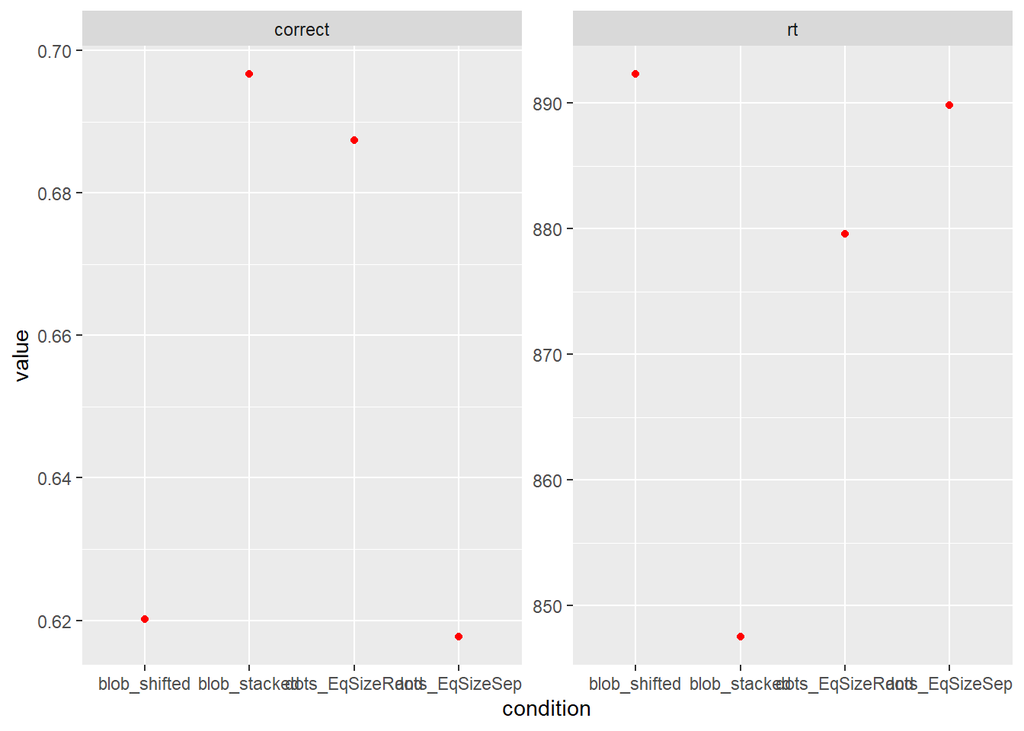

```r
prob_task %>%
  group_by(condition) %>%
  summarise(across(c(rt, correct), mean)) %>%
  pivot_longer(c(rt, correct)) %>%
  ggplot(aes(y = value, x = condition)) +
  geom_point(color = "red") +
  facet_wrap(~name, scales = "free")
```

1. A. This graph shows that the blob_stacked and the dots_Eq_SizeRand conditions have the higher accuracy as compared to the lower accuracies of blob_shifted and dots_EqSizeSep. For the reaction times, it seems that the lower accuracy tasks resulted in the higher reaction times where as the higher accuracy ones resulted in slightly lower reaction times

1. B. The first thing I noticed was the accuracy. I was trying to determine any pattern I can see in accuracy. There is no direct pattern I can tell from the graph alone as per accuracy, but given what each task looks like, I can infer that easily “discernible” tasks will result in a higher accuracy. However, it is clear that easily discernible has a different definition for the blobs vs the dots. Then I looked at the reaction time to see if there was any correlation with the accuracy. I was able to determine that there does seem to be. But the underlying reason from the plots alone can’t be told.

1.C. The information that is hard to notice from the graphs alone is what the correlation is between the high accuracy tasks vs the low accuracy tasks. You can’t necessarily separate it based on blob vs dots as that is clearly not the case here. So there is some other underlying pattern that is resulting in the accuracy differences.

```r
summarized_prob_task<-prob_task%>%
  group_by(SubID, condition)%>%
  summarize(prop_corr = mean(correct, na.rm=TRUE))
head(summarized_prob_task)
```

```
## # A tibble: 6 × 3
## # Groups:   SubID [3]
##   SubID             condition       prop_corr
##   <chr>             <chr>               <dbl>
## 1 R_0SrX3uRtXaupbhv dots_EqSizeRand     0.470
## 2 R_0SrX3uRtXaupbhv dots_EqSizeSep      0.667
## 3 R_0V8O8mrLiHO3Ghj blob_shifted        0.470
## 4 R_0V8O8mrLiHO3Ghj blob_stacked        0.705
## 5 R_1BW5H5J1jQFEpuk blob_shifted        0.530
## 6 R_1BW5H5J1jQFEpuk blob_stacked        0.705
```

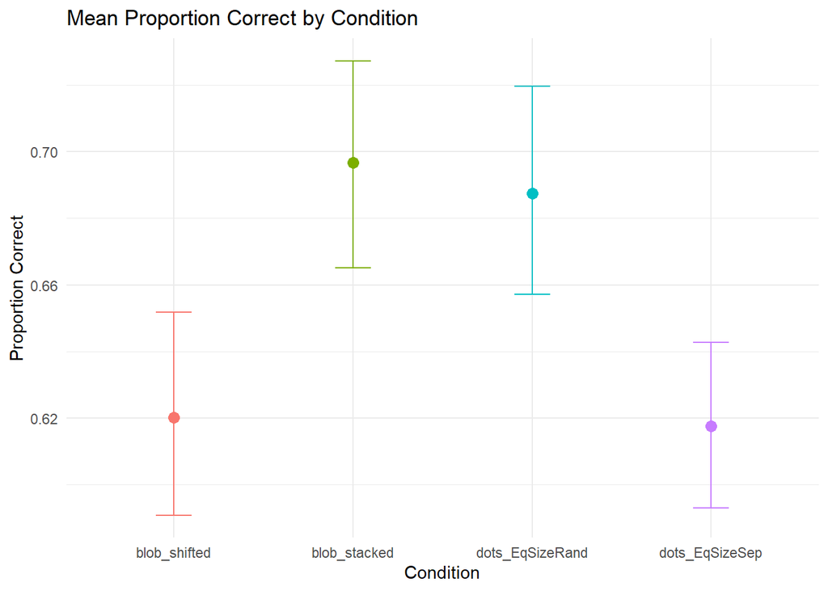

```r
library(dplyr)
library(ggplot2)

ggplot(summarized_prob_task, aes(x = condition, y = prop_corr, color = condition)) +
  stat_summary(fun = mean, geom = "point", size = 3) +
  stat_summary(fun.data = mean_cl_boot, geom = "errorbar", width = 0.2) +
  labs(title = "Mean Proportion Correct by Condition", y = "Proportion Correct", x = "Condition") +
  theme_minimal() +
  theme(legend.position = "none")
```

```r
options(repos = c(CRAN = "https://cloud.r-project.org"))
install.packages("ggdist")
library(ggdist)
library(dplyr)
library(ggplot2)
```

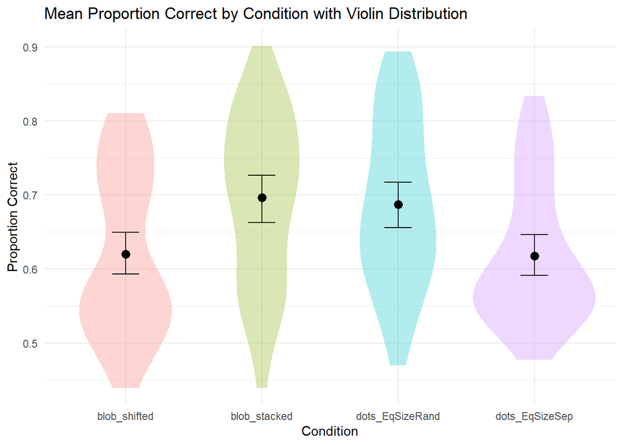

```r
ggplot(summarized_prob_task, aes(x = condition, y = prop_corr, color = condition, fill = condition)) +
  geom_violin(alpha = 0.3, color = NA) +  # Violin plot for distribution shape per each condition.
  stat_summary(fun = mean, geom = "point", size = 3, color = "black") +
  stat_summary(fun.data = mean_cl_boot, geom = "errorbar", width = 0.2, color = "black") +  # CI bars
  labs(title = "Mean Proportion Correct by Condition with Violin Distribution",
       y = "Proportion Correct", x = "Condition") +
  theme_minimal() +
  theme(legend.position = "none")
```

The violin plot shows the shape of the distribution revealing any potential clusters in each group. It allows to determine if there is any skewed distributions. I think we are now able to see more distinct shapes/patterns for each different category that we are considering.

# Assignment 8

```r
prob_task_wrangled<-prob_task%>%
  group_by(SubID, condition)%>%
  summarize(rt = round(mean(rt, na.RM = TRUE)),
            correct = round(mean(correct, na.RM = TRUE),3),
            .groups = "drop")
```

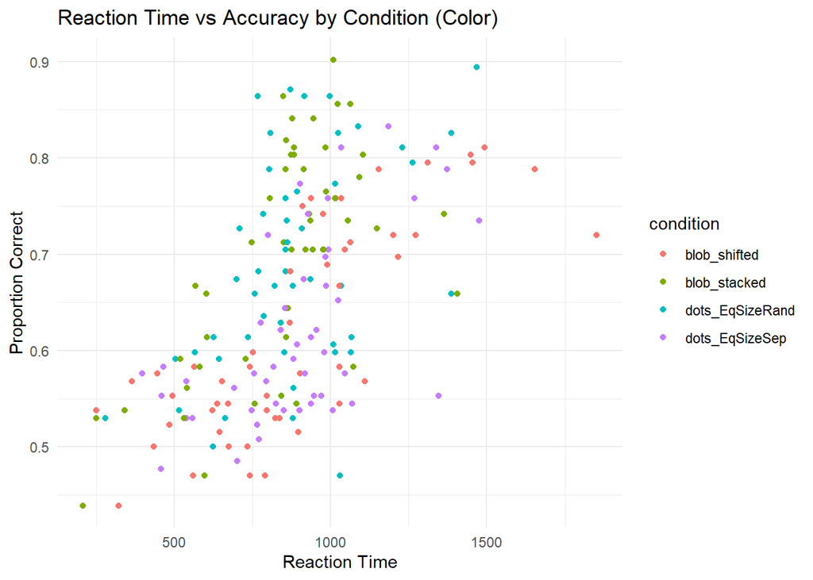

```r
ggplot(prob_task_wrangled,
       aes(x =rt, y=correct, color=condition))+
       geom_point()+
       theme_minimal()+
       labs(title = "Reaction Time vs Accuracy by Condition (Color)", x = "Reaction Time", y= "Proportion Correct")
```

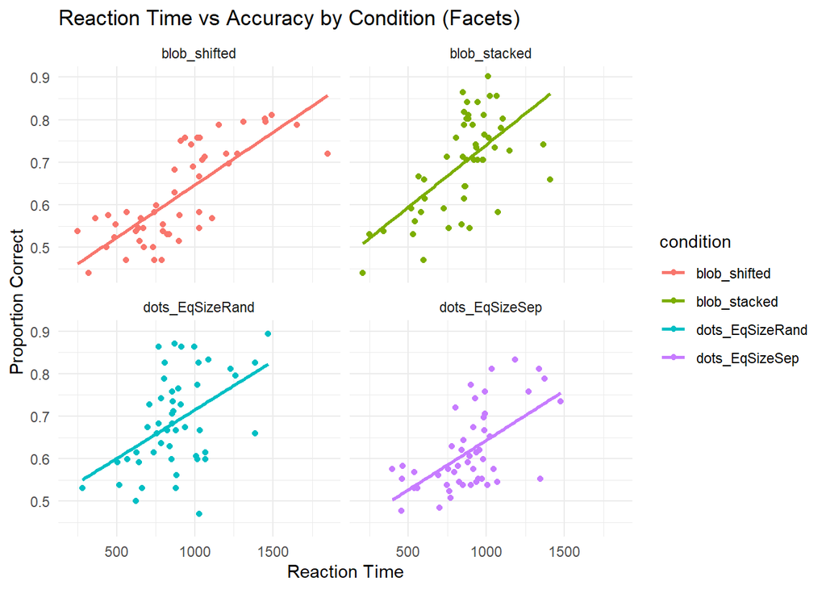

```r
ggplot(prob_task_wrangled, aes(x = rt, y = correct, color = condition)) +
  geom_point() +
  geom_smooth(method = "lm", se = FALSE) +
  facet_wrap(~condition) +
  theme_minimal() +
  labs(
    title = "Reaction Time vs Accuracy by Condition (Facets)",
    x = "Reaction Time",
    y = "Proportion Correct"
  )
```

**OBSERVATION:** It seems they all roughly have the same slope with respect to accuracy as a function of reaction time, when comparing the lines of best fits, but based on the scattered points themselves, it seems that the *dots_EqSizeRand* condition results in better accuracies at lower reaction times compared to the other ones.